# MVLN

North Atlantic Blue Shark

L Kell

06 September, 2023

## Historical Status

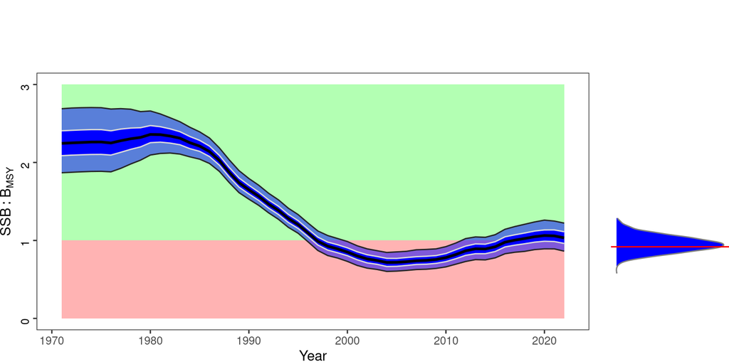

**Figure 1.** Historical trends in $SSB/B_{MSY}$ with marginal plot of current status, ribbons show inter-quartiles and $90_{th}$ percentile, relative to median.

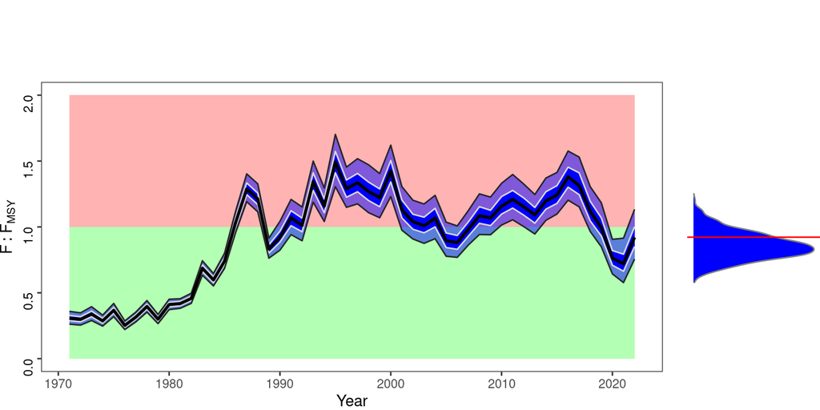

**Figure 2.** Historical trends in $F/F_{MSY}$ with marginal plot of current status, ribbons show inter-quartiles and $90_{th}$ percentile, relative to median.

## Current Status

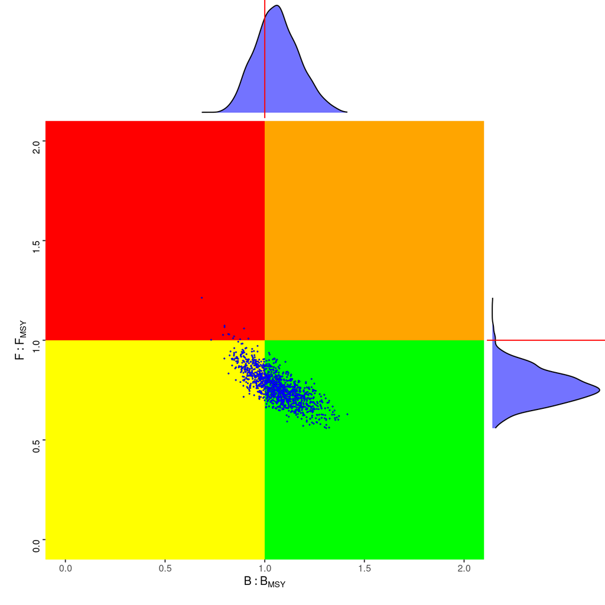

**Figure 3.** Kobe phase plot for $SSB/B_{MSY}$ in 2021 and $F/F_{MSY}$ in 2020

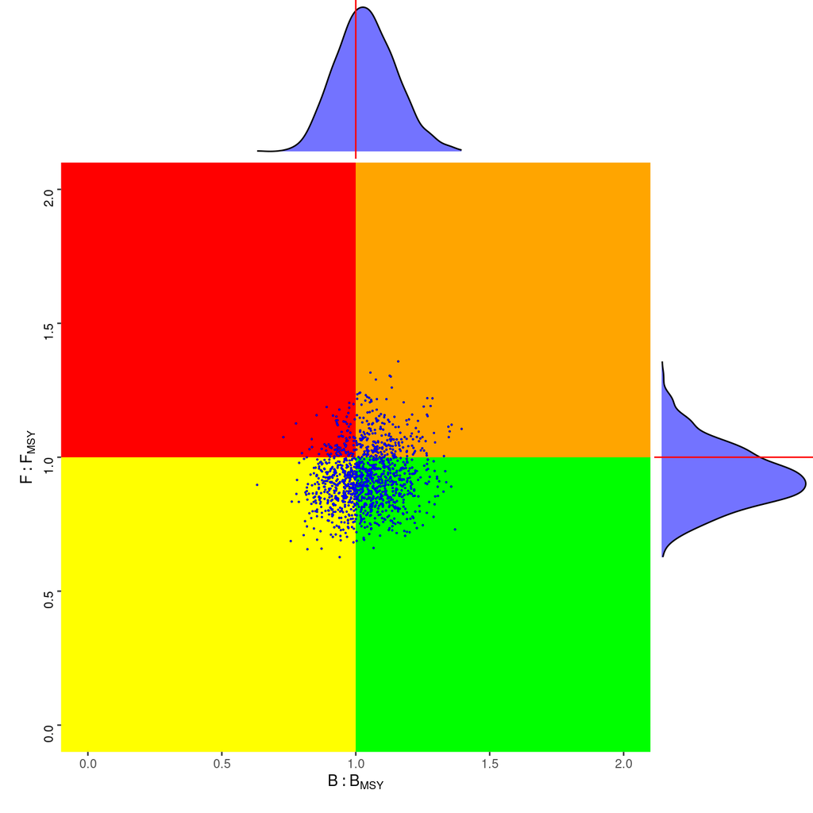

**Figure 4.** Kobe phase plot for $SSB/B_{MSY}$ in 2022 and $F/F_{MSY}$ in 2022

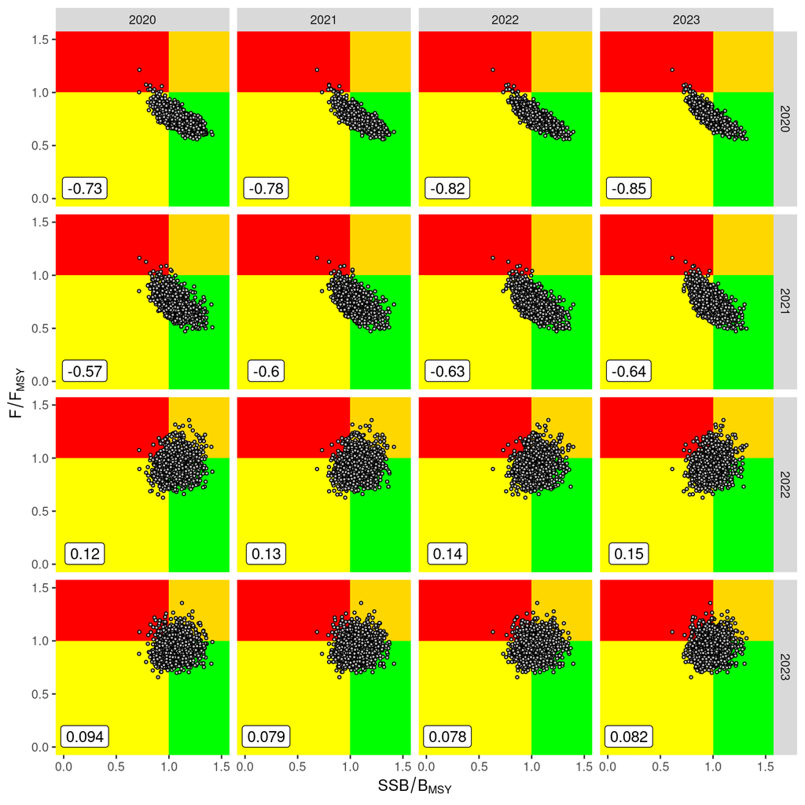

**Figure 5.** Kobe phase plots for historical and $F/F_{MSY}$ forecasts, with correlations.

## Projections

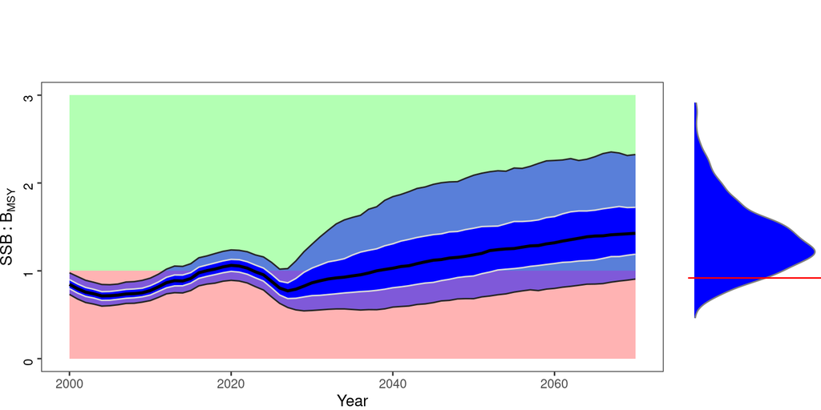

**Figure 6.** Recent historical and future trends in $SSB/B_{MSY}$ and projection for $F_{MSY}$, marginal plot of status in 2032, ribbons show inter-quartiles and $90_{th}$ percentile, relative to median.

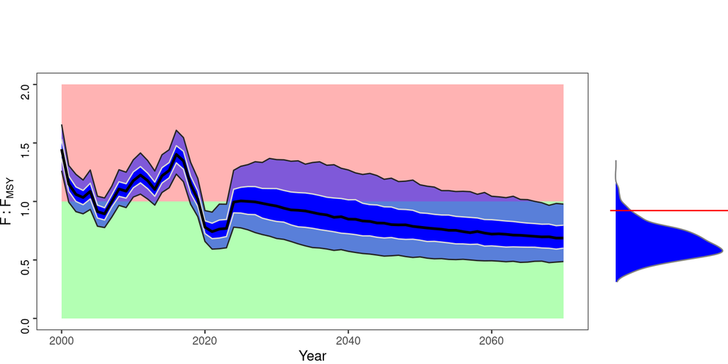

**Figure 7.** Recent historical and future trends in $F/F_{MSY}$ and projection for $F_{MSY}$, marginal plot of status in 2032, ribbons show inter-quartiles and $90_{th}$ percentile, relative to median.

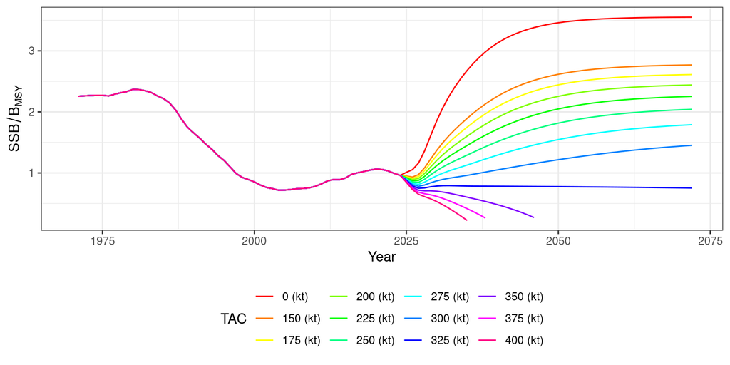

**Figure 8.** Deterministic values of $SSB/B_{MSY}$ for projections

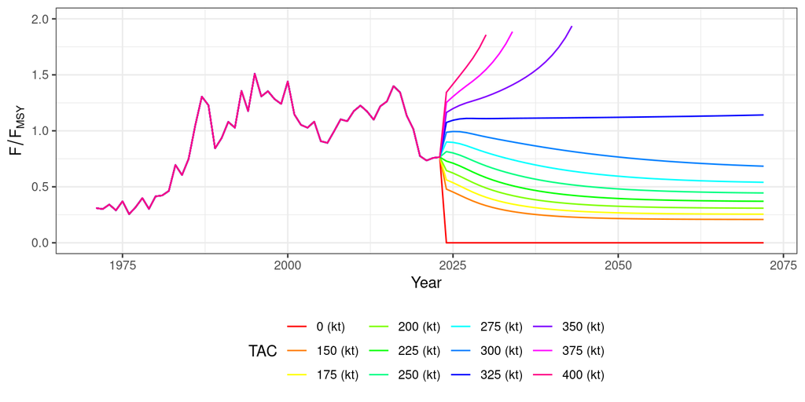

**Figure 9.** Deterministic values of $F/F_{MSY}$ for projections.

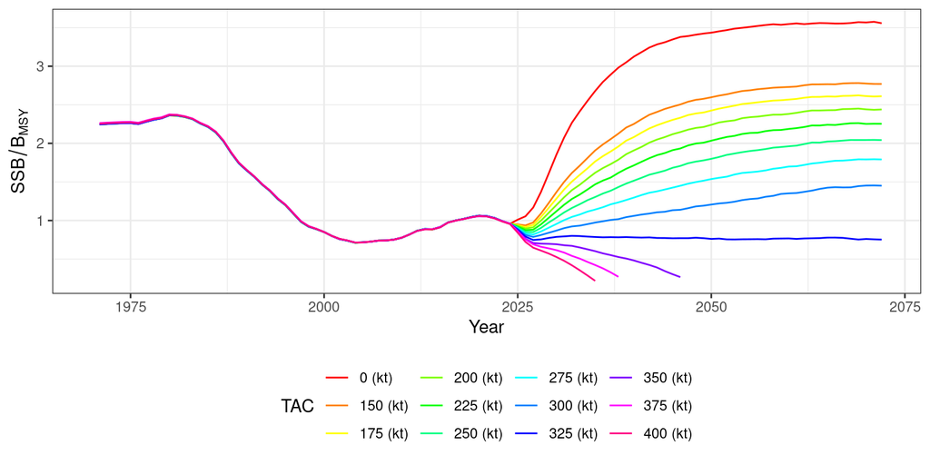

**Figure 10.** Median estimates of $B/SSB_{MSY}$ for projections.

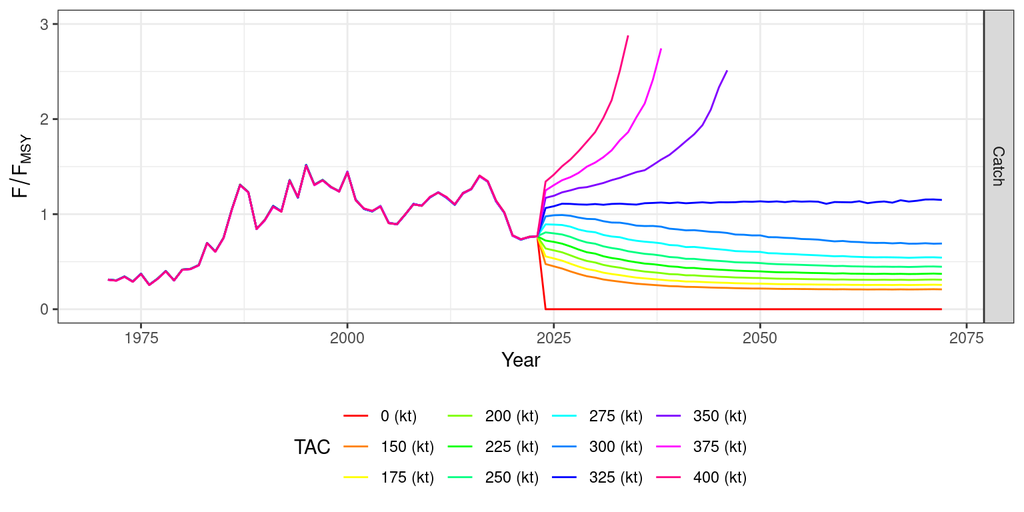

**Figure 11.** Median estimates of $F/SSB_{MSY}$ for projections.

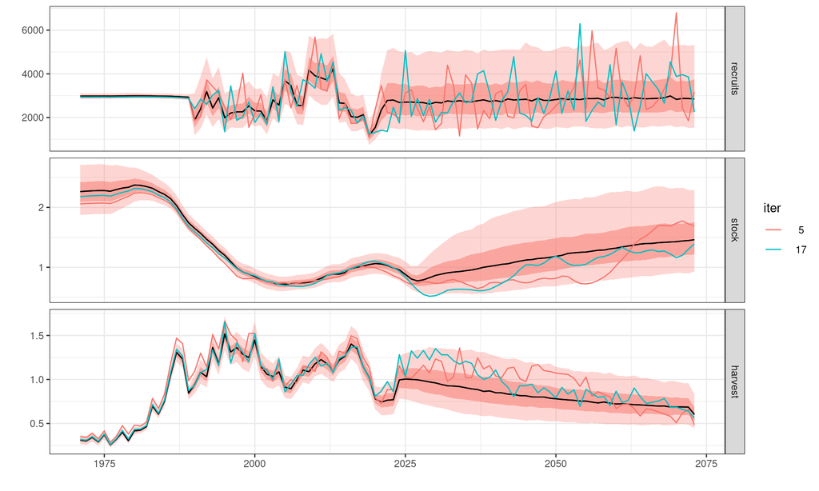

**Figure 12.** Plot of $B/SSB_{MSY}$ & $F/F_{MSY}$ with sample Monte Carlo simulations.

**Table 1.** Covariances from SS

```
            Bratio_2020 Bratio_2021 Bratio_2022 F_2020 F_2021 F_2022
Bratio_2020       1.000       0.976        0.93  -0.74  -0.56  0.083
Bratio_2021       0.976       1.000        0.98  -0.78  -0.60  0.093
Bratio_2022       0.926       0.976        1.00  -0.82  -0.63  0.106
F_2020           -0.736      -0.779       -0.82   1.00   0.60 -0.171
F_2021           -0.564      -0.600       -0.63   0.60   1.00 -0.210
F_2022            0.083       0.093        0.11  -0.17  -0.21  1.000
```

**Table 3.** Estimates of $SSB/B_{MSY}$

```
$ stock
An object of class "FLQuant"
, , unit = unique, season = all, area = unique

     year
quant 2020    2021    2022    2023
  all 1.06319 1.05728 1.03286 0.99326

units:  NA

$ harvest
An object of class "FLQuant"
, , unit = unique, season = all, area = unique

     year
quant 2020    2021    2022    2023
  all 0.77501 0.73481 0.75819 0.76533

units:  NA
```

**Table 4.** Summary of MVLN terminal estimates of $SSB/B_{MSY}$

```
  iter 2020 2021 2022
1  15% 0.96 0.95 0.92
2  50% 1.06 1.05 1.03
```

**Table 5.** Summary of MVLN terminal estimates of $F/F_{MSY}$

```
  iter 2020 2021 2022
1  35% 0.75 0.71 0.72
2  50% 0.78 0.74 0.76
```

**Table 6.** Probability of being in green quadrant.

```
     year
Run   2023  2024  2025  2026  2027  2028  2029   2030
  0   "47%" "38%" "53%" "67%" "90%" "99%" "100%" "100%"
  150 "47%" "37%" "35%" "31%" "43%" "70%" "88%"  "95%"
  175 "47%" "37%" "32%" "26%" "35%" "59%" "79%"  "90%"
  200 "47%" "37%" "30%" "22%" "27%" "49%" "68%"  "82%"
  225 "47%" "37%" "27%" "18%" "21%" "39%" "55%"  "69%"
  250 "47%" "37%" "24%" "15%" "16%" "29%" "44%"  "56%"
  275 "47%" "37%" "22%" "11%" "12%" "20%" "35%"  "42%"
  300 "47%" "32%" "19%" "8%"  "8%"  "14%" "24%"  "29%"
  325 "47%" "23%" "13%" "7%"  "6%"  "9%"  "14%"  "17%"
  350 "46%" "12%" "7%"  "3%"  "3%"  "5%"  "7%"   "8%"
  375 "47%" "6%"  "3%"  "1%"  "1%"  "3%"  "3%"   "4%"
  400 "45%" "2%"  "1%"  "0%"  "0%"  "1%"  "1%"   "1%"
```

**Table 7.** Probability of being over fished.

```
     year
Run   2023  2024  2025  2026  2027  2028  2029  2030
  0   "52%" "61%" "46%" "32%" "9%"  "0%"  "0%"  "0%"
  150 "52%" "62%" "64%" "68%" "56%" "29%" "11%" "4%"
  175 "52%" "62%" "67%" "73%" "64%" "40%" "20%" "9%"
  200 "52%" "62%" "69%" "77%" "72%" "50%" "31%" "17%"
  225 "52%" "62%" "72%" "81%" "78%" "60%" "44%" "30%"
  250 "52%" "61%" "74%" "84%" "83%" "70%" "55%" "43%"
  275 "52%" "61%" "76%" "88%" "87%" "79%" "64%" "57%"
  300 "52%" "61%" "78%" "90%" "91%" "84%" "74%" "69%"
  325 "52%" "62%" "81%" "92%" "92%" "89%" "83%" "78%"
  350 "53%" "63%" "85%" "94%" "95%" "92%" "88%" "86%"
  375 "52%" "63%" "86%" "95%" "96%" "94%" "92%" "90%"
  400 "54%" "64%" "87%" "96%" "97%" "96%" "95%" "93%"
```

**Table 8.** Probability of overfishing.

```
     year
Run   2023 2024  2025  2026  2027  2028  2029  2030
  0   "3%" "0%"  "0%"  "0%"  "0%"  "0%"  "0%"  "0%"
  150 "3%" "0%"  "0%"  "0%"  "0%"  "0%"  "0%"  "0%"
  175 "3%" "0%"  "0%"  "0%"  "0%"  "0%"  "0%"  "0%"
  200 "3%" "0%"  "0%"  "0%"  "0%"  "0%"  "0%"  "0%"
  225 "3%" "2%"  "1%"  "1%"  "0%"  "0%"  "0%"  "0%"
  250 "3%" "9%"  "8%"  "7%"  "5%"  "4%"  "3%"  "2%"
  275 "3%" "23%" "24%" "23%" "21%" "19%" "17%" "14%"
  300 "3%" "44%" "46%" "47%" "46%" "43%" "40%" "39%"
  325 "3%" "65%" "68%" "70%" "70%" "68%" "67%" "68%"
  350 "3%" "83%" "86%" "86%" "87%" "86%" "86%" "86%"
  375 "5%" "92%" "94%" "95%" "94%" "94%" "93%" "93%"
  400 "3%" "97%" "98%" "98%" "98%" "98%" "97%" "98%"
```